# Outbreak detection using machine learning and early warning signals

Andrew Tredennick

2019-01-31

```r
library(tidyverse)
library(dplyr)
library(spaero)
library(neuralnet)
knitr::opts_chunk$set(message = FALSE)
```

# Motivation

From my modeling work, we know that critical slowing down (as evidenced by early warning signals) anticipates measles emergence as $R_E$ approaches 1. This implies that CSD could be used to detect outbreaks, so long as the outbreaks are unique to $R_E$ being exceptionally large or exceeding 1. Unfortunately, my modeling work also shows that $R_E$ tends to fluctuate seasonally from below to above 1, and outbreaks tend to depend on sparking from external infections. So, CSD might not be able to detect outbreak (though it might) but it might be able to evaluate outbreak risk in terms of number of cases (there is some evidence of this in the `ews-timing.Rmd` notebook).

I am going to start by fitting a neural network model aimed at classifying outbreaks based on EWS values in the interepidemic times. I will then move to a neural net regression aimed at predicting the future number of cases, which can serve as an outbreak risk factor.

# Methods

## Define outbreak years

First, I need to define “outbreak” years in the observed data. To do this, I will fit an exponential mixture model to the distribution of cumulative cases in each year. The boundary between the two exponentials will serve as the cut-off for “outbreak” and “non-outbreak” years. I will fit the model using incidence data (cases/population size) so that data from all four cities can be pooled; this is helpful given the small sample size for each city (11 years).

Here I read in the data, summarize the weekly data in cumulative yearly case counts, and then convert cases to incidence based on population size.

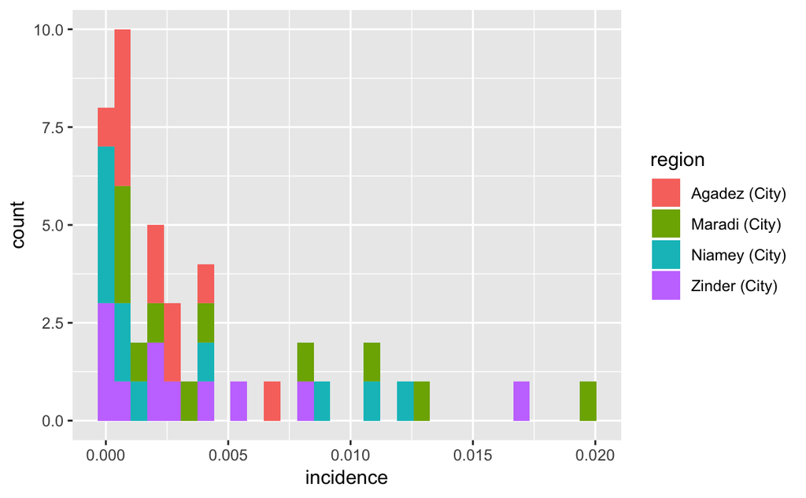

```r
# Load measles data
fname <- "../../data/clean-data/weekly-measles-incidence-niger-cities-clean.RDS"
measles_data <- readRDS(fname) %>%
  filter(year > 1994)  # remove 1994 year, only used for modeling
# Make population df
pop_data <- tibble(
  region = c("Agadez (City)", "Maradi (City)",
             "Niamey (City)", "Zinder (City)"),
  pop = c(118224, 267249, 1027000, 322935)  # from Wikipedia
)
# Summarize to cumulative yearly cases
cusum_data <- measles_data %>%
  group_by(region, year) %>%
  summarise(cases = sum(cases)) %>%
  left_join(pop_data, by = "region") %>%  # add in population data
  mutate(incidence = cases/pop)  # calculate incidence
# Plot the distribution
ggplot(cusum_data, aes(x = incidence)) +
  geom_histogram(aes(fill = region), bins = 30)
```

Now I can sort the incidence data from smallest to largest and then fit the mized exponential distribution model.

```r
x <- sort(cusum_data$incidence)  # extract incidence data
# Fit null distribution for starting values
fit1 <- MASS::fitdistr(x, "exponential")
# Define likelihood of mixed exponential
mixexplik <- function(p, lambda1, lambda2) {
  z <- p*dexp(x,lambda1) + (1-p)*dexp(x,lambda2)
  return(-sum(log(z)))
}
# Fit the model
mle_fit <- suppressWarnings(  # ignore warnings about bad guesses
  stats4::mle(minuslogl = mixexplik,
              start= list(p = 0.2,
                          lambda1 = as.numeric(fit1$estimate),
                          lambda2 = as.numeric(fit1$estimate)),
              method="Nelder-Mead")
)
# Calculate the boundary incidence between small and large outbreaks
boundary <- qexp(p = 0.5, rate = mle_fit@coef["p"]*mle_fit@coef["lambda1"])
```

Based on the mixed exponential model, the cut-off between small and large outbreaks is when incidence equals 0.0011. I will use this cut-off to define years as `outbreak_year = TRUE/FALSE`.

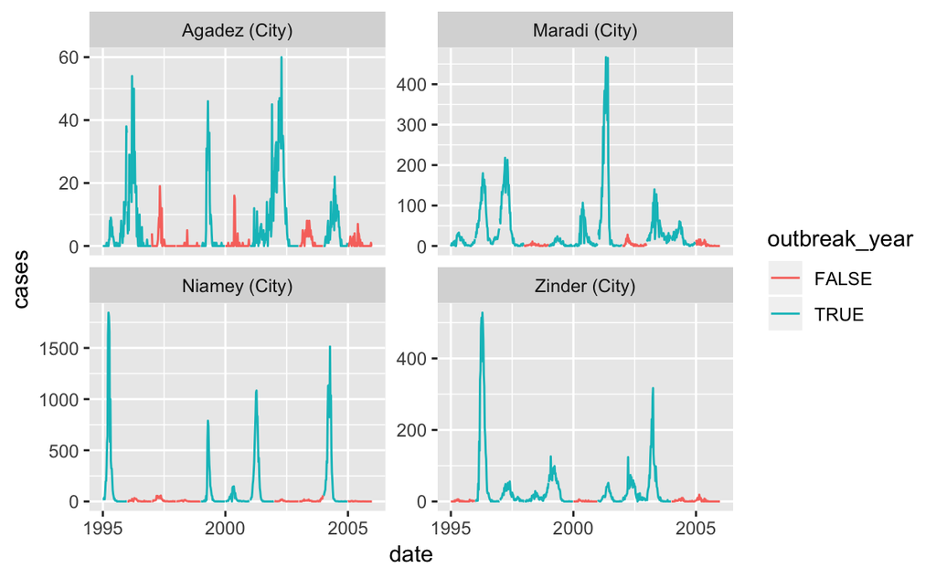

```r
outbreak_ids <- cusum_data %>%
  dplyr::mutate(
    outbreak_year = ifelse(incidence < boundary, FALSE, TRUE)
  ) %>%
  dplyr::select(region, year, outbreak_year)
measles_data <- measles_data %>%
  left_join(outbreak_ids, by = c("region", "year"))
ggplot(measles_data, aes(x = date, y = cases, color = outbreak_year, group = year)) +
  geom_line() +
  facet_wrap(~region, scales = "free_y")
```

## Calculate early warning signals

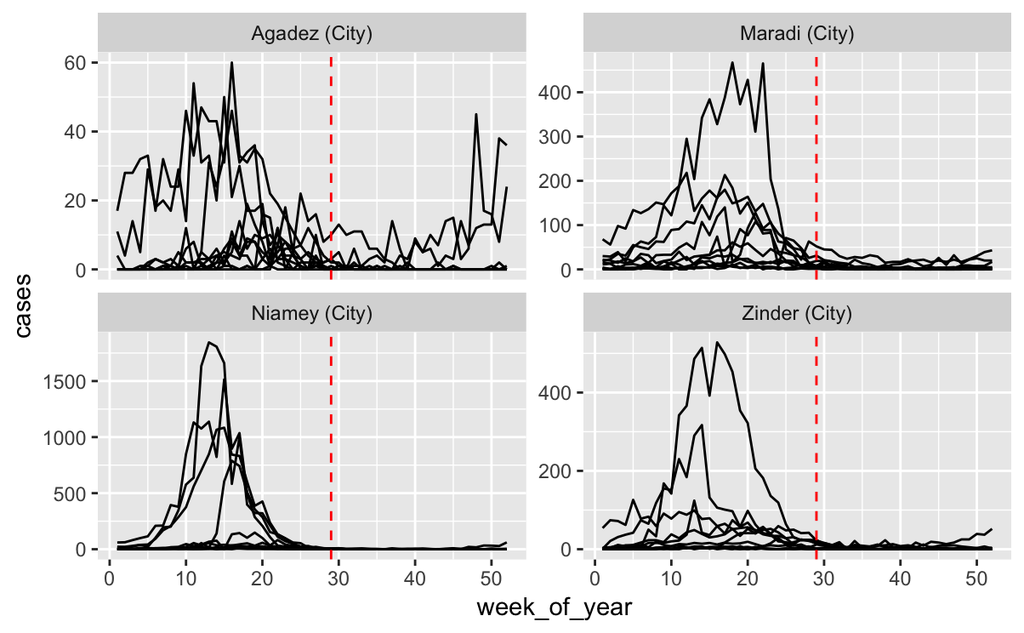

```r
ggplot(measles_data, aes(x = week_of_year, y = cases, group = year)) +
  geom_line() +
  geom_vline(aes(xintercept = 29), color = "red", linetype = 2) +
  facet_wrap(~region, scales = "free_y")
```

Now I will calculate early warning signals for the interepidemic periods, after first defining a new column `season_year` based on the beginning of the interepidemic period. Basically, I want each “season” to begin in week 30 of the calendar year and run through week 29 of the following calendar year.

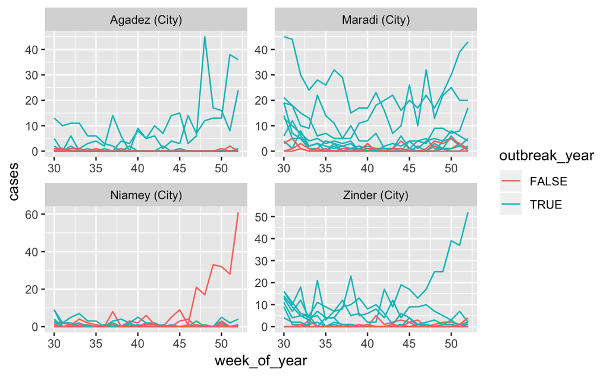

```r
measles_data <- measles_data %>%
   mutate(
    season_year = ifelse(week_of_year > 29, year + 1, year)
  )
ggplot(filter(measles_data, week_of_year %in% 30:52),
       aes(x = week_of_year, y = cases, group = season_year)) +
  geom_line(aes(color = outbreak_year)) +
  facet_wrap(~region, scales = "free")
```

```r
regions <- unique(measles_data$region)
season_years <- unique(measles_data$season_year)
all_ews <- tibble()  # empty tibble for storage
for(do_region in regions){
  for(do_season in season_years){
    tmp_data <- measles_data %>%
      filter(region == do_region) %>%
      filter(season_year == do_season)

    tmp_cases <- tmp_data %>% pull(cases)
    tmp_stats <- get_stats(x = tmp_cases, center_trend = "local_constant",
                           center_kernel = "uniform", center_bandwidth = 16,
                           stat_trend = "local_constant",
                           stat_kernel = "uniform", stat_bandwidth = 16,
                           lag = 1, backward_only = TRUE)

    tmp_out <- tmp_data %>%
      mutate(week_of_ews = 1:n()) %>%
      bind_cols(as_tibble(tmp_stats$stats))

    all_ews <- bind_rows(all_ews, tmp_out)
  }  # end season-year loop
}  # end region loop
```

```
the standard deviation is zerothe standard deviation is zerothe standard deviation is zerothe standard deviation is zerothe standard deviation is zero
```

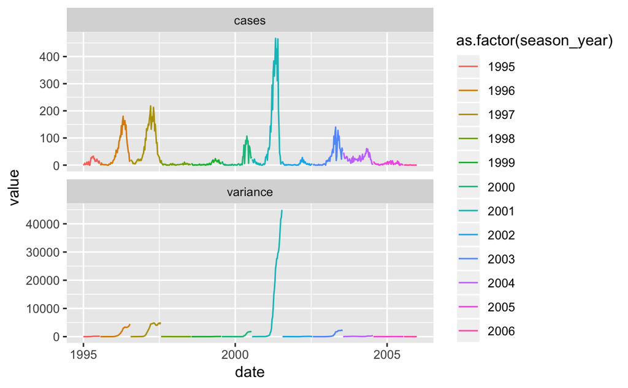

```r
# Plot example EWS over time
all_ews %>%
  filter(region == "Maradi (City)") %>%
  dplyr::select(region, date, season_year, cases, variance) %>%
  gather(key = "variable", value = "value", -region, -date, -season_year) %>%
  ggplot(aes(x = date, y = value)) +
  geom_line(aes(color = as.factor(season_year))) +
  facet_wrap(~variable, scales = "free_y", ncol = 1)
```

## Use neural net to classify outbreak years from EWS

```r
# Make super-wide dataframe
feature_data <- all_ews %>%
  dplyr::select(-year, -date, -obs_week, -cases, -time, -week_of_ews) %>%
  filter(season_year > 1995) %>%
  filter(week_of_year %in% c(30:52)) %>%
  gather(key = "ews_metric", value = "ews_value",
         -region, -week_of_year, -outbreak_year, -season_year) %>%
  filter(ews_metric %in% c("autocorrelation", "variance", "mean")) %>%
  mutate(week_id = letters[week_of_year - 29]) %>%
  dplyr::select(-week_of_year) %>%
  unite(ews_week, week_id, ews_metric) %>%
  spread(key = ews_week, value = ews_value) %>%
  arrange(region, season_year) %>%
  replace(., is.na(.), 0)
# Scale all input features to [0,1]
scale01 <- function(x) {
    (x - min(x))/(max(x) - min(x))
}
feature_data <- feature_data %>%
  mutate_at(vars(a_autocorrelation:w_variance),
            funs(scale01)) %>%
  select_if(~sum(!is.na(.)) > 0)  # remove columns with only NA(N) values
```

Now I can fit the model.

```r
regions <- unique(feature_data$region)
pred_df <- tibble()  # empty tibble for storage
for(do_region in regions){
  hold_out_region <- do_region

  train_data <- feature_data %>%
    filter(region != hold_out_region) %>%
    dplyr::select(-region, -season_year)
  test_data <- feature_data %>%
    filter(region == hold_out_region) %>%
    dplyr::select(-region, -season_year)

  X_formula <- paste(colnames(train_data[2:ncol(train_data)]), collapse = "+")
  y_formula <- "outbreak_year ~"
  nnet_formula <- as.formula(paste(y_formula, X_formula))
  mod1 <- neuralnet(formula = nnet_formula, data = train_data,
                    linear.output = FALSE, err.fct = "ce", rep = 200,
                    likelihood = TRUE, hidden = 1)

  pr.nn <- compute(mod1, test_data[,2:ncol(test_data)])
  pr.nn <- pr.nn$net.result
  tmp_df <- tibble(
    predicted_region = hold_out_region,
    observed = test_data$outbreak_year,
    predicted = pr.nn[,1]
  )
  pred_df <- bind_rows(pred_df, tmp_df)
}
nn_pred <- ROCR::prediction(pred_df$predicted, pred_df$observed)
perf <- ROCR::performance(nn_pred, measure = "auc")
auc <- round(as.numeric(perf@y.values),digits = 2)
pref <- ROCR::performance(nn_pred, "tpr", "fpr")
table_df <- pred_df %>%
  mutate(predicted = as.logical(round(predicted)))
cmatrix <- table(table_df[,2:3])
tpr <- cmatrix[2,2] / sum(cmatrix[2,])
fpr <- cmatrix[1,1] / sum(cmatrix[1,])
print(cmatrix)
```

```
        predicted
observed FALSE TRUE
   FALSE    16    2
   TRUE      6   20
```

```r
print(tpr)
```

```
[1] 0.7692307692
```

```r
print(fpr)
```

```
[1] 0.8888888889
```

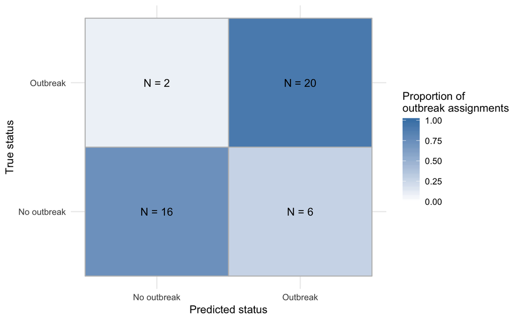

```r
assign_mat <- tibble(
  value = as.numeric(cmatrix),
  predicted_status = c("No outbreak", "Outbreak", "No outbreak", "Outbreak"),
  true_status = c("No outbreak", "No outbreak", "Outbreak", "Outbreak")
) %>%
  group_by(true_status) %>%
  mutate(sample_size = sum(value)) %>%
  ungroup() %>%
  mutate(value = value/sample_size)
roc_df <- tibble(
  fpr = as.numeric(pref@x.values[[1]]),
  tpr = as.numeric(pref@y.values[[1]])
)
ggplot(assign_mat, aes(x = predicted_status, y = true_status)) +
  geom_tile(aes(fill = value), color = "grey", size = 0.5) +
  geom_text(aes(label = paste("N =", value*sample_size))) +
  scale_fill_gradient(limits = c(0,1), low = "white", high = "steelblue",
                      name = "Proportion of\noutbreak assignments") +
  labs(x = "Predicted status", y = "True status") +
  theme_minimal()
```

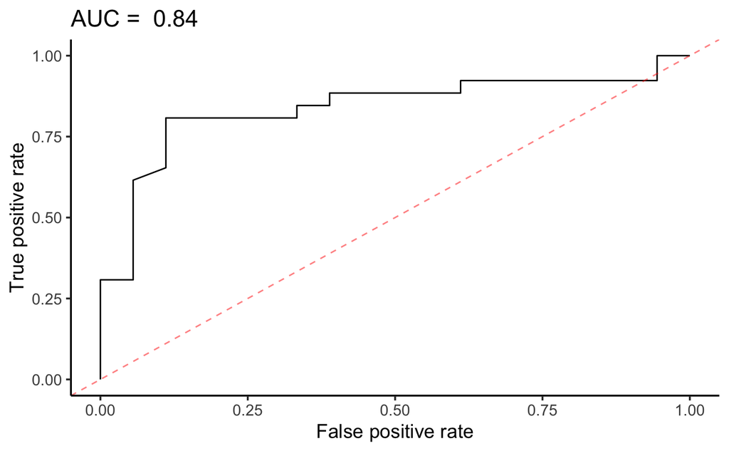

```r
ggplot(roc_df, aes(fpr, tpr)) +
  geom_line() +
  geom_abline(aes(intercept = 0, slope = 1), col = "red", alpha = 0.5, linetype = 2) +
  labs(x = "False positive rate", y = "True positive rate") +
  ggtitle(paste("AUC = ", auc)) +
  theme_classic(base_size = 14)
```

Compare to a model using just mean cases.

```r
# Make super-wide dataframe
feature_data <- all_ews %>%
  dplyr::select(-year, -date, -obs_week, -cases, -time, -week_of_ews) %>%
  filter(season_year > 1995) %>%
  filter(week_of_year %in% c(30:52)) %>%
  gather(key = "ews_metric", value = "ews_value",
         -region, -week_of_year, -outbreak_year, -season_year) %>%
  filter(ews_metric %in% c("mean")) %>%
  mutate(week_id = letters[week_of_year - 29]) %>%
  dplyr::select(-week_of_year) %>%
  unite(ews_week, week_id, ews_metric) %>%
  spread(key = ews_week, value = ews_value) %>%
  arrange(region, season_year) %>%
  replace(., is.na(.), 0)
# Scale all input features to [0,1]
scale01 <- function(x) {
    (x - min(x))/(max(x) - min(x))
}
feature_data <- feature_data %>%
  mutate_at(vars(a_mean:w_mean),
            funs(scale01)) %>%
  select_if(~sum(!is.na(.)) > 0)  # remove columns with only NA(N) values
regions <- unique(feature_data$region)
pred_df <- tibble()  # empty tibble for storage
for(do_region in regions){
  hold_out_region <- do_region

  train_data <- feature_data %>%
    filter(region != hold_out_region) %>%
    dplyr::select(-region, -season_year)
  test_data <- feature_data %>%
    filter(region == hold_out_region) %>%
    dplyr::select(-region, -season_year)

  X_formula <- paste(colnames(train_data[2:ncol(train_data)]), collapse = "+")
  y_formula <- "outbreak_year ~"
  nnet_formula <- as.formula(paste(y_formula, X_formula))
  mod1 <- neuralnet(formula = nnet_formula, data = train_data,
                    linear.output = FALSE, err.fct = "ce",
                    likelihood = TRUE, rep = 200)

  pr.nn <- compute(mod1, test_data[,2:ncol(test_data)])
  pr.nn <- pr.nn$net.result
  tmp_df <- tibble(
    predicted_region = hold_out_region,
    observed = test_data$outbreak_year,
    predicted = pr.nn[,1]
  )
  pred_df <- bind_rows(pred_df, tmp_df)
}
nn_pred <- ROCR::prediction(pred_df$predicted, pred_df$observed)
perf <- ROCR::performance(nn_pred, measure = "auc")
auc <- round(as.numeric(perf@y.values),digits = 2)
pref <- ROCR::performance(nn_pred, "tpr", "fpr")
table_df <- pred_df %>%
  mutate(predicted = as.logical(round(predicted)))
cmatrix <- table(table_df[,2:3])
tpr <- cmatrix[2,2] / sum(cmatrix[2,])
fpr <- cmatrix[1,1] / sum(cmatrix[1,])
print(cmatrix)
```

```
        predicted
observed FALSE TRUE
   FALSE    13    5
   TRUE      5   21
```

```r
print(tpr)
```

```
[1] 0.8076923077
```

```r
print(fpr)
```

```
[1] 0.7222222222
```

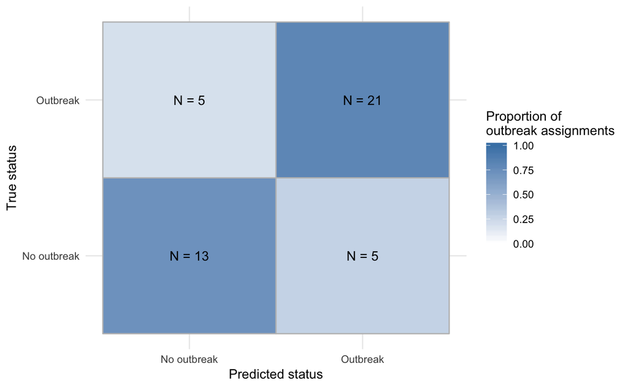

```r
assign_mat <- tibble(
  value = as.numeric(cmatrix),
  predicted_status = c("No outbreak", "Outbreak", "No outbreak", "Outbreak"),
  true_status = c("No outbreak", "No outbreak", "Outbreak", "Outbreak")
) %>%
  group_by(true_status) %>%
  mutate(sample_size = sum(value)) %>%
  ungroup() %>%
  mutate(value = value/sample_size)
roc_df <- tibble(
  fpr = as.numeric(pref@x.values[[1]]),
  tpr = as.numeric(pref@y.values[[1]])
)
ggplot(assign_mat, aes(x = predicted_status, y = true_status)) +
  geom_tile(aes(fill = value), color = "grey", size = 0.5) +
  geom_text(aes(label = paste("N =", value*sample_size))) +
  scale_fill_gradient(limits = c(0,1), low = "white", high = "steelblue",
                      name = "Proportion of\noutbreak assignments") +
  labs(x = "Predicted status", y = "True status") +
  theme_minimal()
```

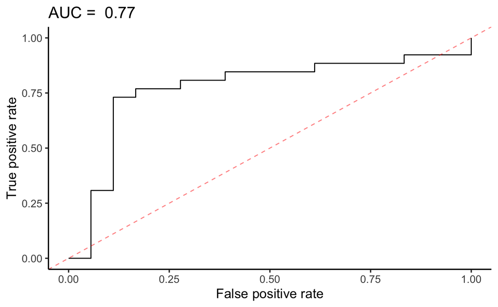

```r
ggplot(roc_df, aes(fpr, tpr)) +
  geom_line() +
  geom_abline(aes(intercept = 0, slope = 1), col = "red", alpha = 0.5, linetype = 2) +
  labs(x = "False positive rate", y = "True positive rate") +
  ggtitle(paste("AUC = ", auc)) +
  theme_classic(base_size = 14)
```